# Plotting

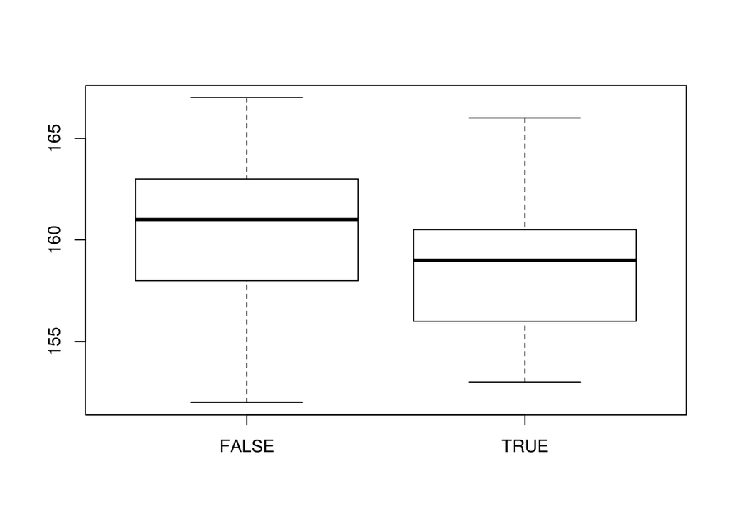

```r
boxplot(bumpus$TL~bumpus$survived)
```

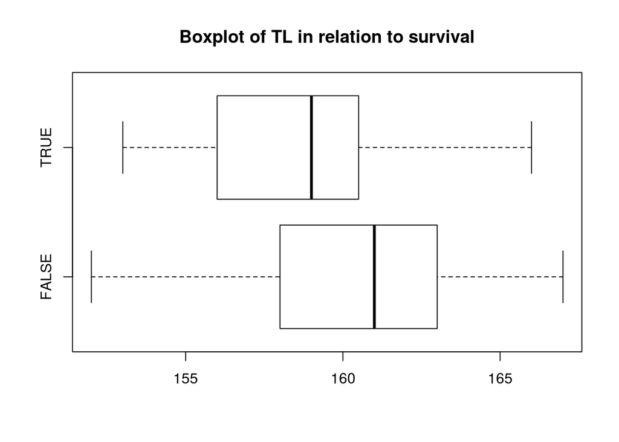

```r
boxplot(bumpus$TL~bumpus$survived, main="Boxplot of TL in relation to survival", horizontal=T)
```

```r
bx.bumpus <- boxplot(bumpus$TL~bumpus$survived, plot=F)
bx.bumpus
```

```
## $stats
##      [,1]  [,2]
## [1,]  152 153.0
## [2,]  158 156.0
## [3,]  161 159.0
## [4,]  163 160.5
## [5,]  167 166.0
## attr(,"class")
##     FALSE
## "integer"
##
## $n
## [1] 64 72
##
## $conf
##          [,1]     [,2]
## [1,] 160.0125 158.1621
## [2,] 161.9875 159.8379
##
## $out
## numeric(0)
##
## $group
## numeric(0)
##
## $names
## [1] "FALSE" "TRUE"
```

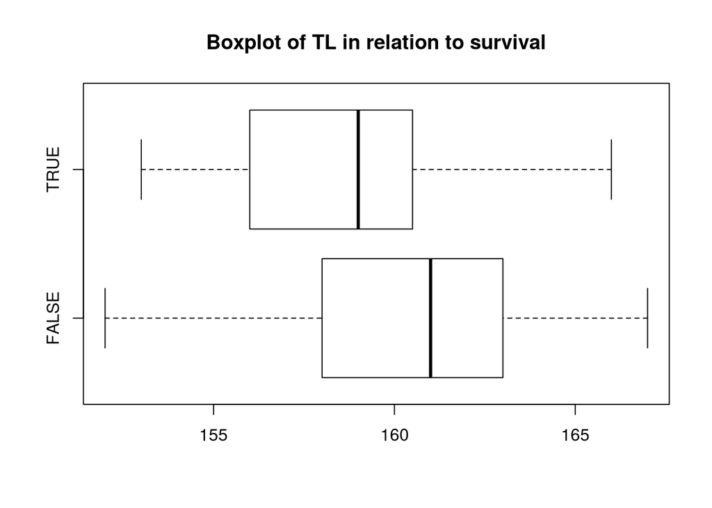

```r
bxp(bx.bumpus, main="Boxplot of TL in relation to survival", horizontal=T)
```

# *BARPLOTS*

See ?barplot for details

```r
survived <- table(bumpus$survived)
survived
```

```
##
## FALSE  TRUE
##    64    72
```

```r
survived <- survived / nrow(bumpus)
survived
```

```
##
##     FALSE      TRUE
## 0.4705882 0.5294118
```

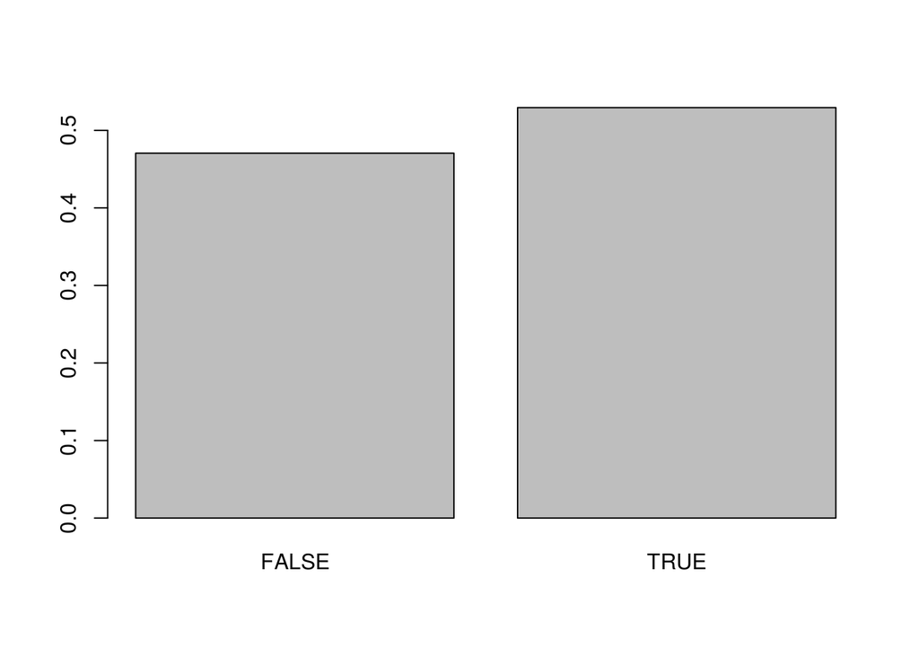

```r
barplot(survived)
```

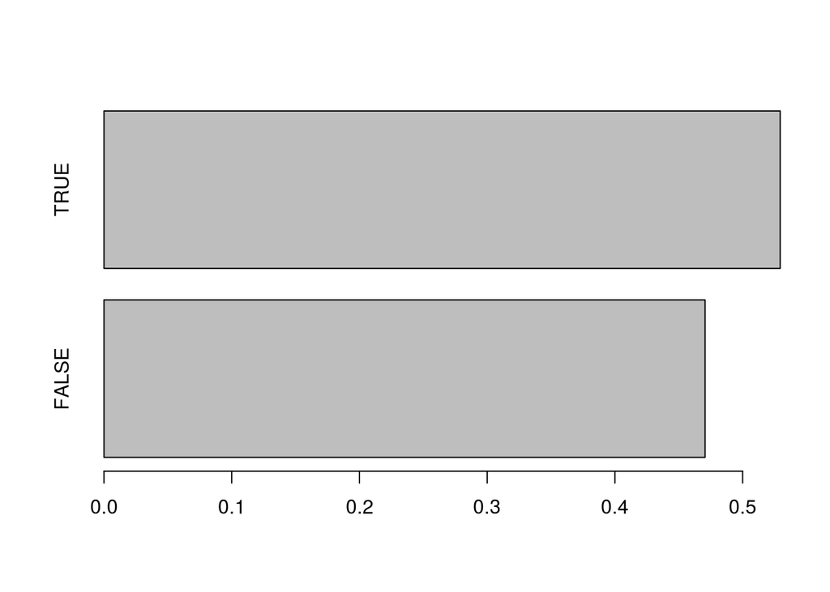

```r
barplot(survived, horiz=T)
```

```r
survivedbysex <- table(bumpus$sex, bumpus$survived) /  nrow(bumpus)
survivedbysex
```

```
##
##         FALSE      TRUE
##   f 0.2058824 0.1544118
##   m 0.2647059 0.3750000
```

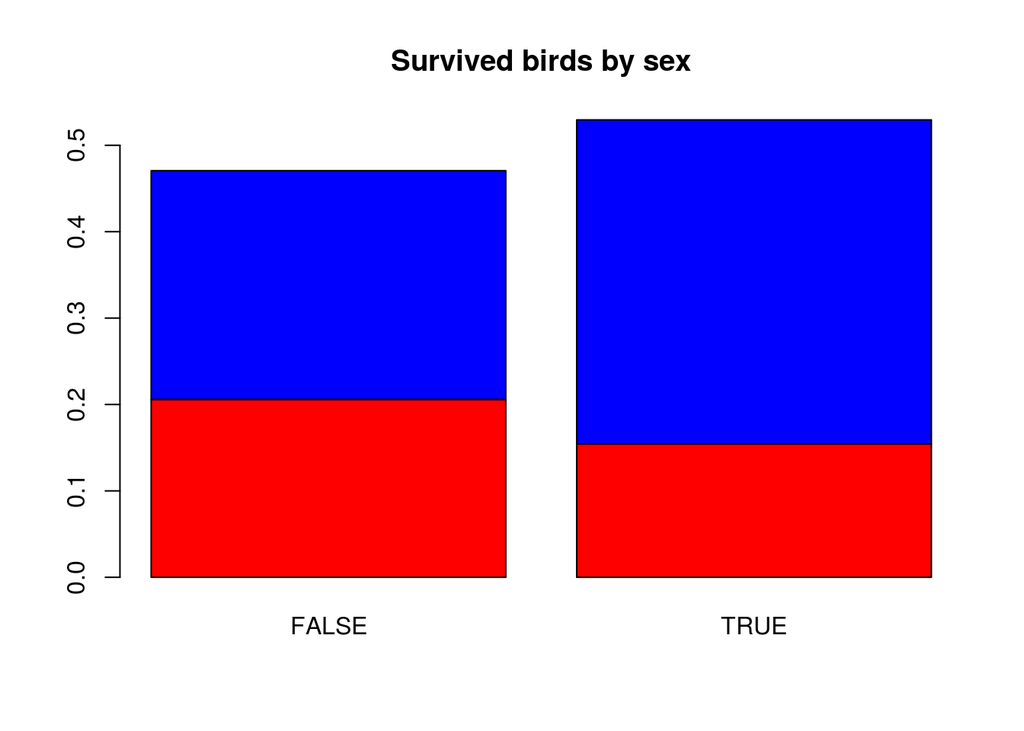

```r
barplot(survivedbysex, main="Survived birds by sex", col=c("red", "blue"))
```

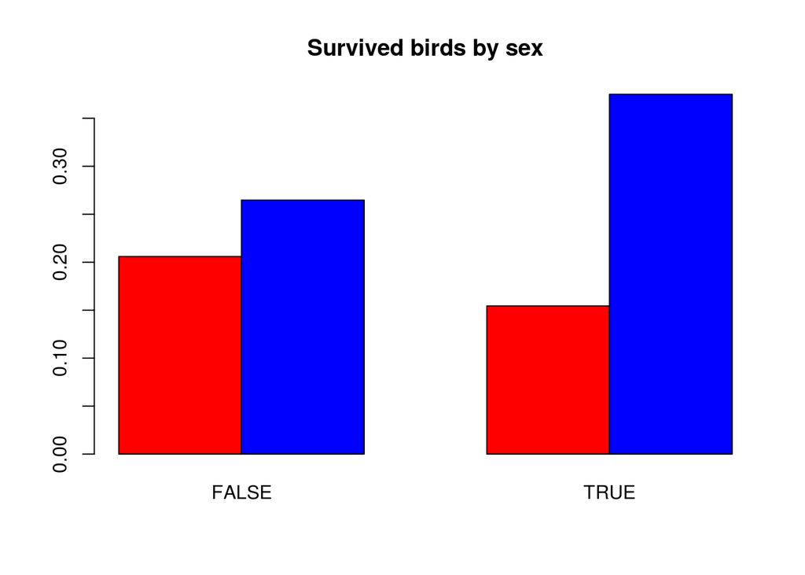

```r
barplot(survivedbysex, main="Survived birds by sex", col=c("red", "blue"),
        beside=T)
```

# *PIECHARTS*

See ?pie for details

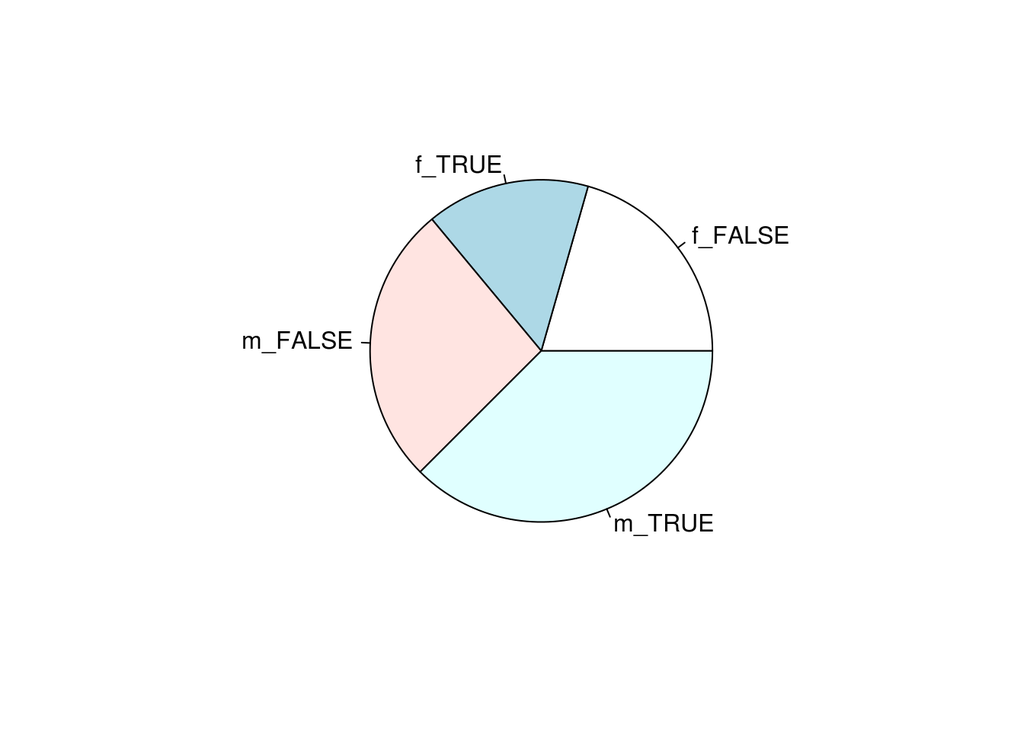

```r
sex.surv <- paste(bumpus$sex, bumpus$survived, sep="_")
fr.bumpus <- table(sex.surv)/length(sex.surv)
pie(fr.bumpus)
```

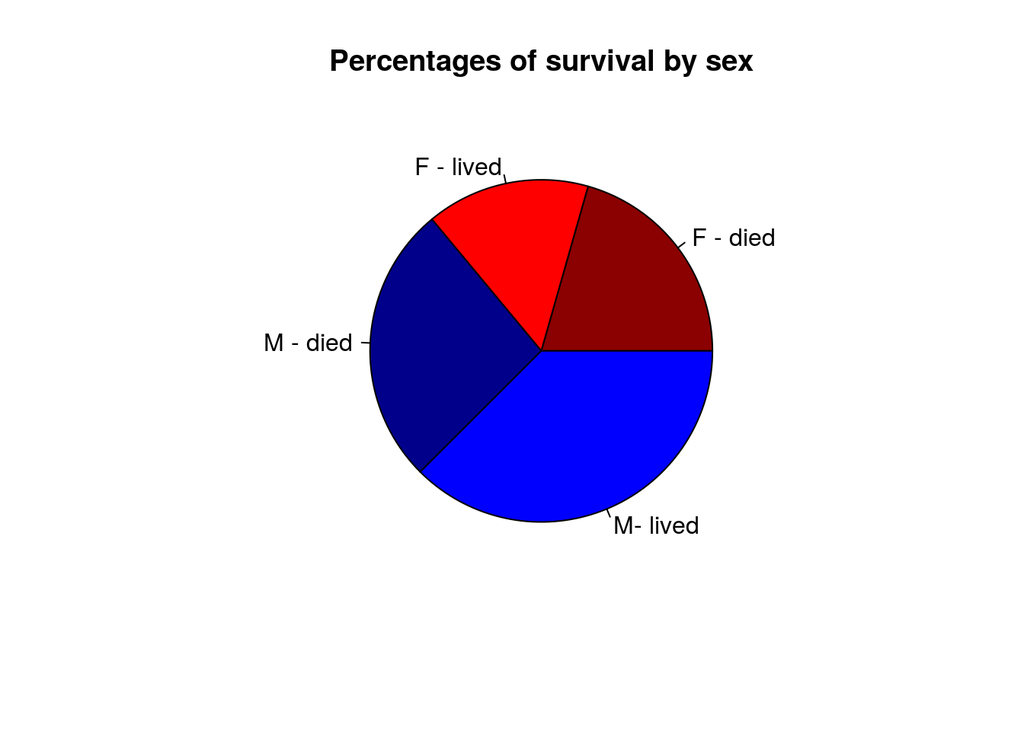

```r
pie(fr.bumpus,
    labels=c("F - died", "F - lived", "M - died", "M- lived"),
    main="Percentages of survival by sex",
    col=c("darkred", "red", "darkblue", "blue"))
```

## **PLOTS AS LAYERS**

Plots can be built by adding layers. As usually occur with R, there are different ways of doing the same thing. For example, you can represent points as circles connected by lines following these three approaches:

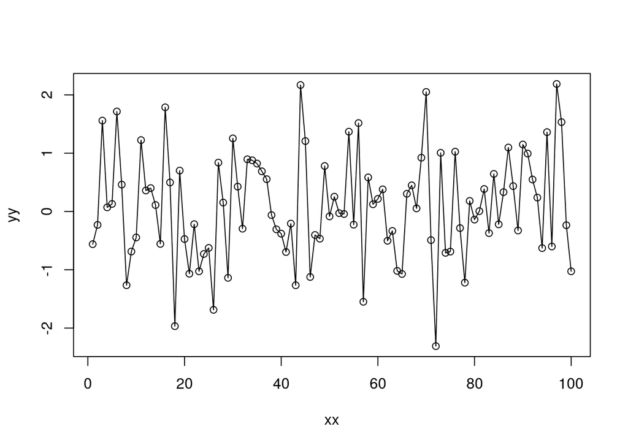

```r
xx <- 1:100
set.seed(123)
yy <- rnorm(100)

# 1.- Plot points and add lines:
plot(xx, yy)
lines(xx,yy)
```

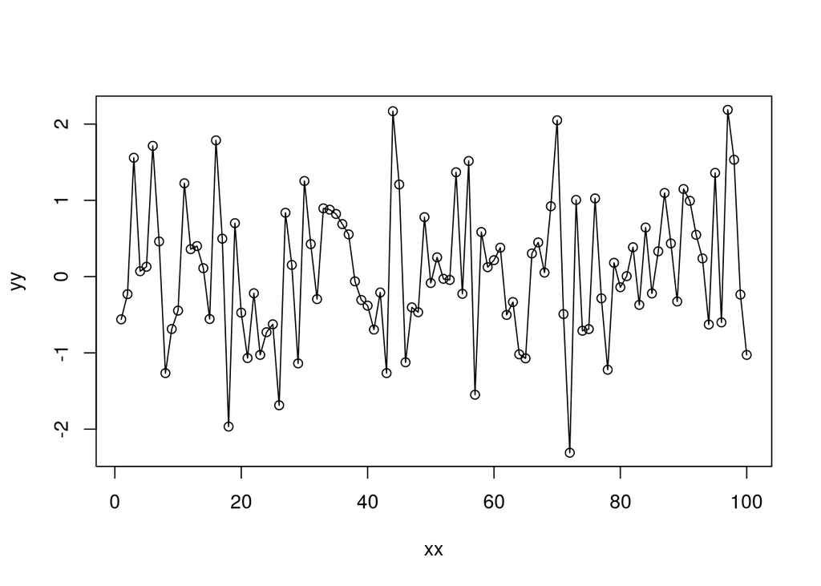

```r
# 2.- Plot lines and add points:
 plot(xx, yy,type="l")
 points(xx, yy)
```

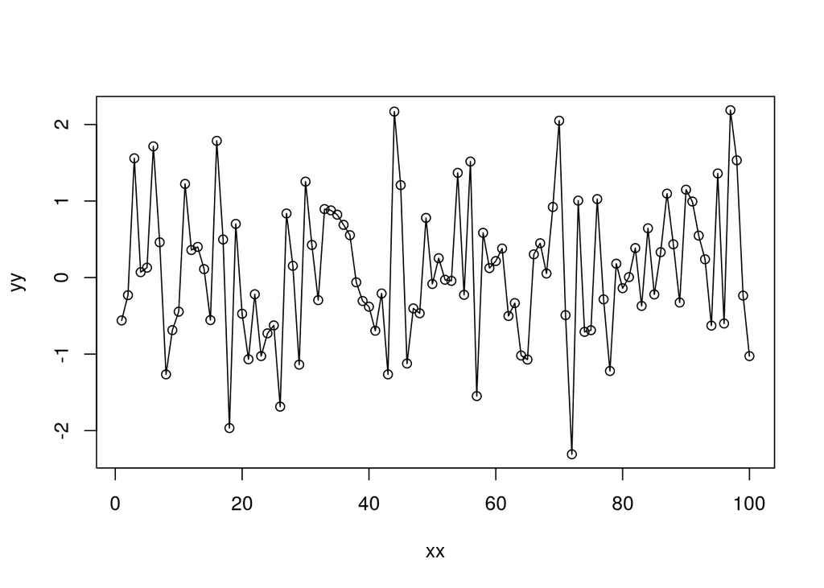

```r
# 3.- Using the argument type="o" (overlapped)
 plot(xx, yy,type="o")
```

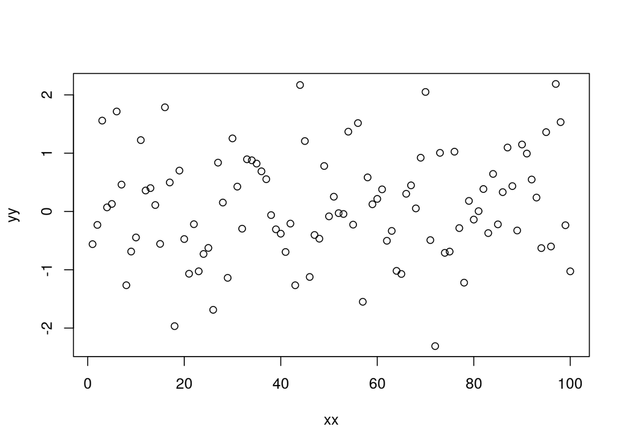

```r
# NOTE: There are other options, the default is "p" (points)
 plot(xx, yy,type="p")
```

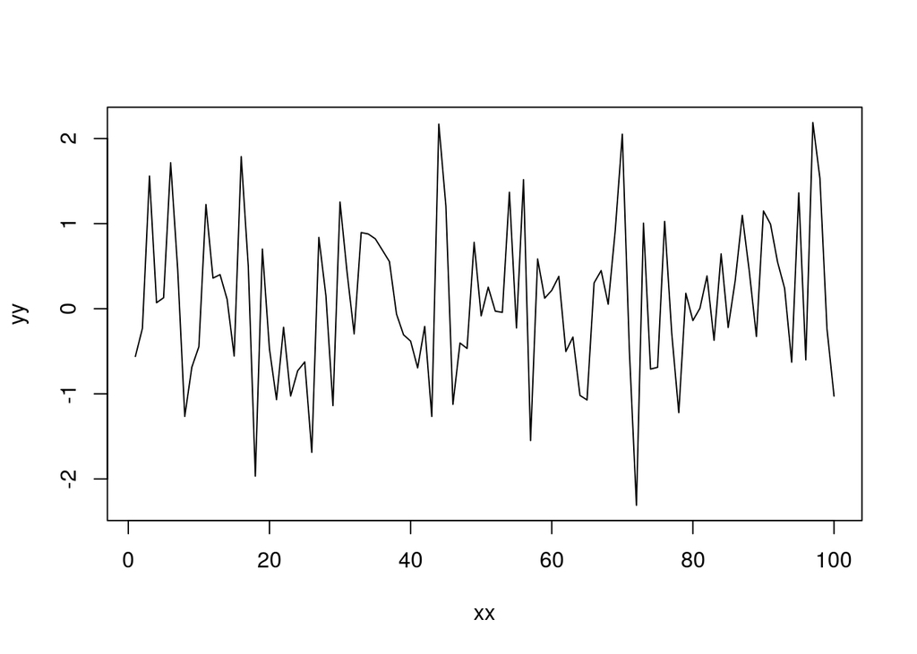

```r
 plot(xx, yy,type="l")
```

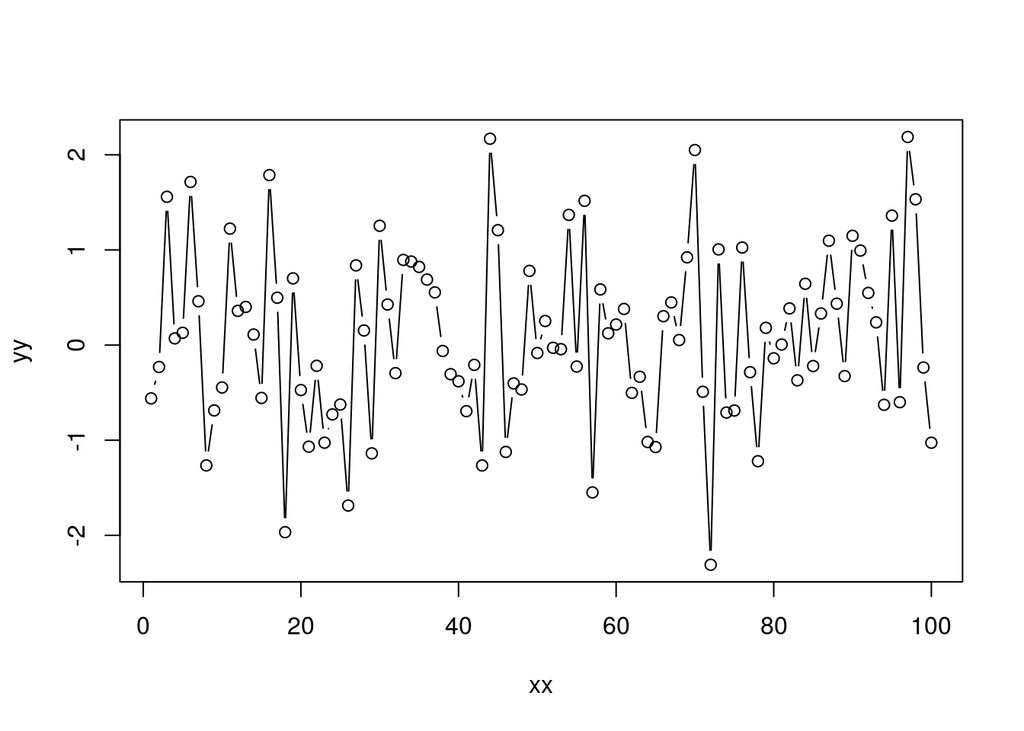

```r
 plot(xx, yy,type="b")
```

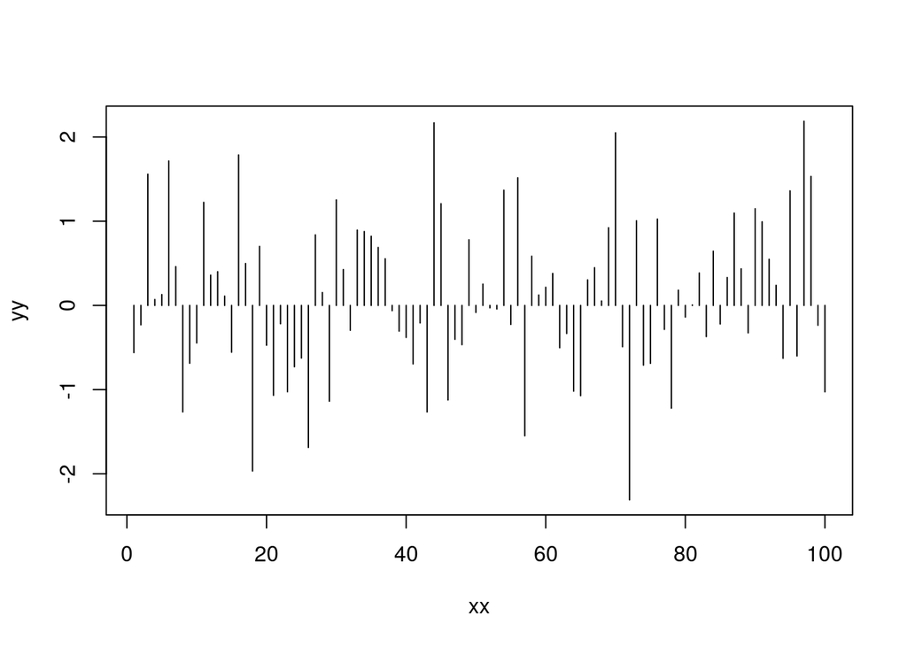

```r
 plot(xx, yy,type="h")
```

Linear regressions and curves can also be added as layers:

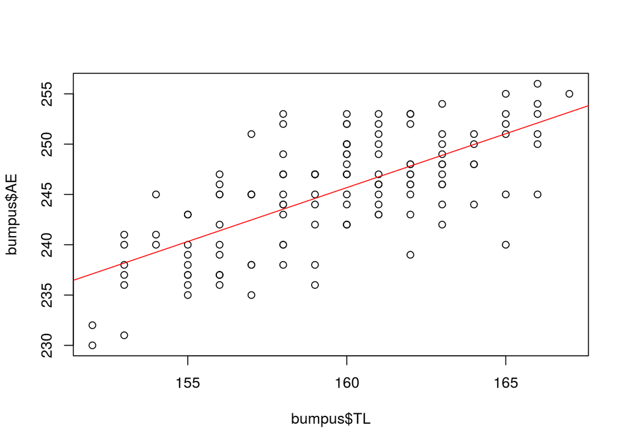

```r
# adding regressions
plot(bumpus$TL, bumpus$AE)
fit <- lm(AE ~ TL, data = bumpus)
abline(fit, col='red')
```

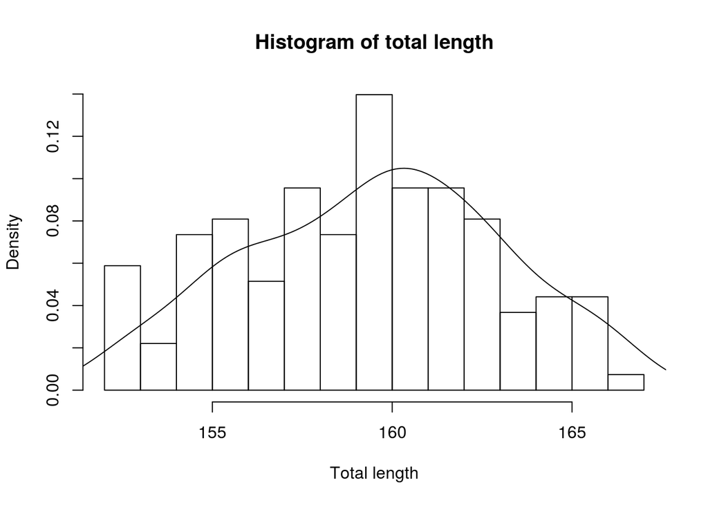

```r
hist(bumpus$TL, main="Histogram of total length", xlab="Total length",
     breaks=20, freq=F)
lines(density(bumpus$TL))   # Add a Kernel density plot
```

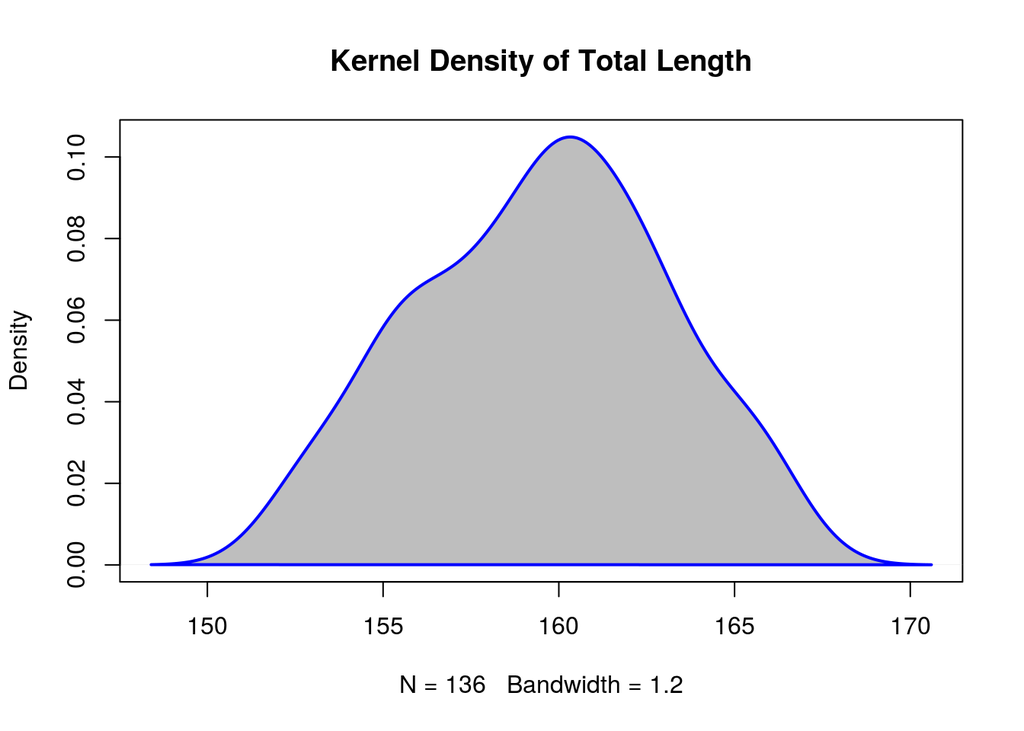

```r
plot(density(bumpus$TL), main="Kernel Density of Total Length")
polygon(density(bumpus$TL), col="grey" , border="blue", lwd=2)
```

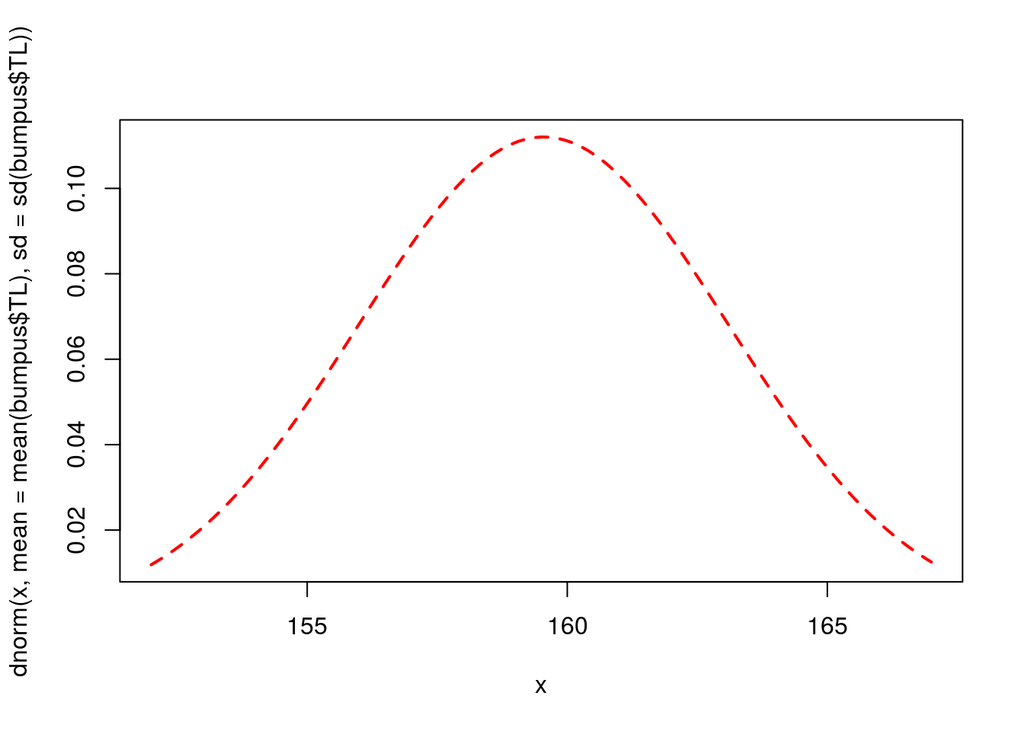

```r
curve(dnorm(x, mean=mean(bumpus$TL), sd=sd(bumpus$TL)), col="red", lwd=2,  lty=2,xlim=range(bumpus$TL))                     # Add a normal curve
```

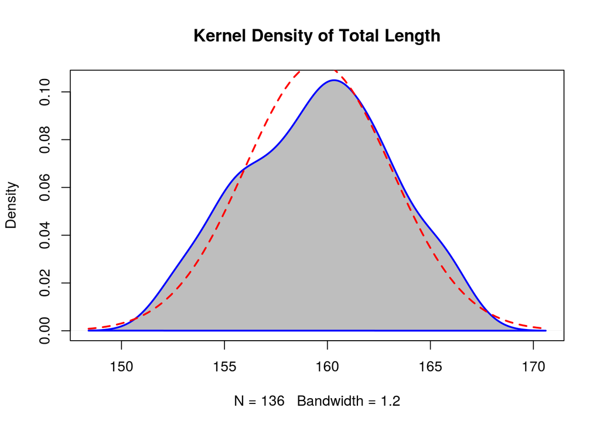

```r
plot(density(bumpus$TL), main="Kernel Density of Total Length")
polygon(density(bumpus$TL), col="grey" , border="blue", lwd=2)
curve(dnorm(x, mean=mean(bumpus$TL), sd=sd(bumpus$TL)), add=T, col="red", lwd=2,
      lty=2)                    # Add a normal curve
```

## **LAYERS FROM SCRATCH**

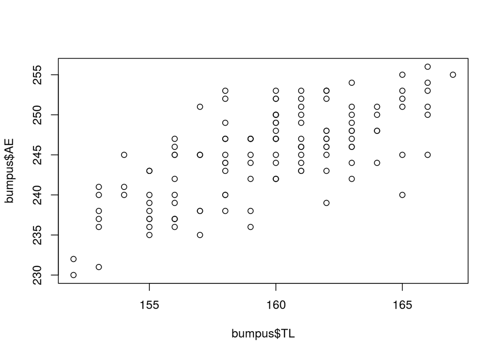

```r
plot(bumpus$TL, bumpus$AE) # Check the axis dimensions
```

```r
range(bumpus$TL)
```

```
## [1] 152 167
```

```r
range(bumpus$AE)
```

```
## [1] 230 256
```

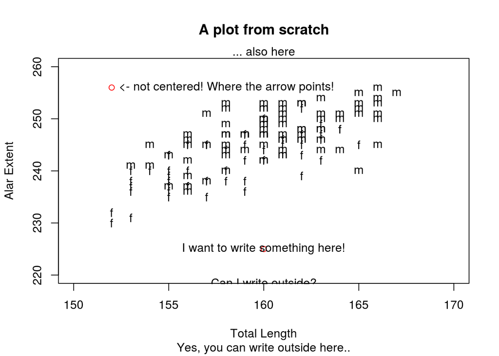

```r
#dev.new()
plot.new()
plot.window(c(150, 170), c(220, 260))
axis(1)
axis(2)
box()
title(main="A plot from scratch", xlab="Total Length", ylab="Alar Extent")
text(bumpus$TL, bumpus$AE, bumpus$sex)


points(160, 225, col='red')
text(160, 225, "I want to write something here!")

points(152, 256, col='red')
text(152, 256, "<- not centered! Where the arrow points!", pos=4)

text(160, 218.5, "Can I write outside?")

mtext("Yes, you can write outside here..", side=1, line=4)
mtext("... also here", side=3)
```

## **Controlling plot aesthetics**

Almost anything you want to control in R plotting is available through par()

```r
?par
```

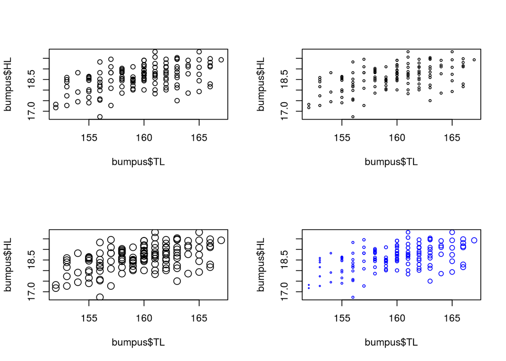

```r
layout(matrix(1:4, nrow=2, byrow=T))
plot(bumpus$HL~bumpus$TL)

# POINT STYLE ####
# Point size
# Half the default value
plot(bumpus$HL~bumpus$TL, cex=0.5)
# Larger than default
plot(bumpus$HL~bumpus$TL, cex=1.5)
# Depending on
plot(bumpus$HL~bumpus$TL, cex=10*(log(bumpus$TL)-5),col="blue")
```

```r
# Point colour (see ColorChart.pdf and execute):
colors()
```

```
##   [1] "white"                "aliceblue"            "antiquewhite"
##   [4] "antiquewhite1"        "antiquewhite2"        "antiquewhite3"
##   [7] "antiquewhite4"        "aquamarine"           "aquamarine1"
##  [10] "aquamarine2"          "aquamarine3"          "aquamarine4"
##  [13] "azure"                "azure1"               "azure2"
##  [16] "azure3"               "azure4"               "beige"
##  [19] "bisque"               "bisque1"              "bisque2"
##  [22] "bisque3"              "bisque4"              "black"
##  [25] "blanchedalmond"       "blue"                 "blue1"
##  [28] "blue2"                "blue3"                "blue4"
##  [31] "blueviolet"           "brown"                "brown1"
##  [34] "brown2"               "brown3"               "brown4"
##  [37] "burlywood"            "burlywood1"           "burlywood2"
##  [40] "burlywood3"           "burlywood4"           "cadetblue"
##  [43] "cadetblue1"           "cadetblue2"           "cadetblue3"
```

[output cut: 204 more lines]

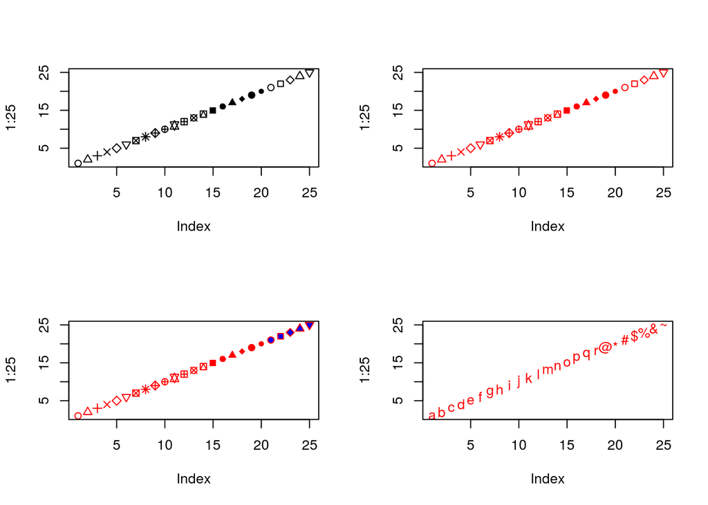

```r
# Point type (see pch.png and execute):
plot(1:25,pch=1:25)
# Depending on the shape, col will affect the line or the background:
plot(1:25,pch=1:25,col="red")
# Some of the shapes may be filled with different colors using bg.
plot(1:25,pch=1:25,col="red",bg="blue")
# In addition, you can use any character as pch:
plot(1:25,pch=c(letters[1:18],"@","*","#","$","%","&","~"),col="red",bg="blue")
```

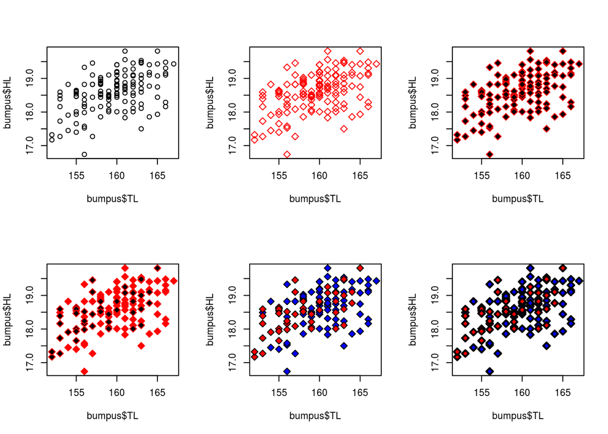

```r
# Going back to the bumpus
layout(matrix(1:6,ncol=3,byrow=T))

plot(bumpus$HL~bumpus$TL)

plot(bumpus$HL~bumpus$TL, cex=1.25, col="red", pch=23)

# Point background colour
plot(bumpus$HL~bumpus$TL, cex=1.25, col="red", pch=23, bg="black")

# Plotting by group
plot(bumpus$HL~bumpus$TL, cex=1.25, col="red", pch=23, bg=bumpus$sex)
plot(bumpus$HL~bumpus$TL, cex=1.25, col="black", pch=23,
     bg=ifelse(bumpus$sex=="f", "red", "blue"))

# Line thickness
plot(bumpus$HL~bumpus$TL, cex=1.25, col="black", pch=23,
     bg=ifelse(bumpus$sex=="f", "red", "blue"), lwd=2)
```

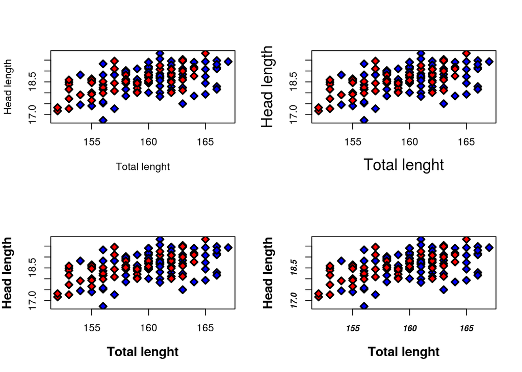

```r
# AXES STYLE ####
# Axes titles
layout(matrix(1:4, nrow=2, byrow=T))
plot(bumpus$HL~bumpus$TL, cex=1.25, col="black", pch=23,
     bg=ifelse(bumpus$sex=="f", "red", "blue"), lwd=2,
     xlab="Total lenght", ylab="Head length")

# Axes label font size
plot(bumpus$HL~bumpus$TL, cex=1.25, col="black", pch=23,
     bg=ifelse(bumpus$sex=="f", "red", "blue"), lwd=2,
     xlab="Total lenght", ylab="Head length",
     cex.lab=1.5)

# Axes font types
# For labels
plot(bumpus$HL~bumpus$TL, cex=1.25, col="black", pch=23,
     bg=ifelse(bumpus$sex=="f", "red", "blue"), lwd=2,
     xlab="Total lenght", ylab="Head length",
     cex.lab=1.25, font.lab=2)

# For axis values
plot(bumpus$HL~bumpus$TL, cex=1.25, col="black", pch=23,
     bg=ifelse(bumpus$sex=="f", "red", "blue"), lwd=2,
     xlab="Total lenght", ylab="Head length",
     cex.lab=1.25, font.lab=2, cex.axis=0.8, font.axis=4)
```

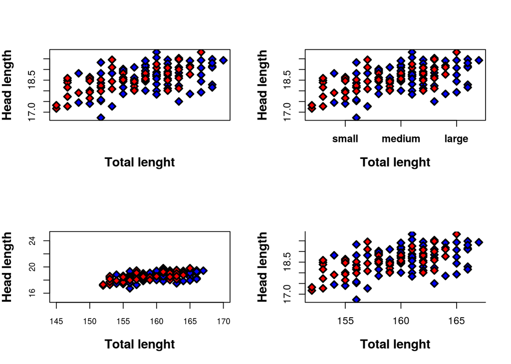

```r
# Suppressing the axes
plot(bumpus$HL~bumpus$TL, cex=1.25, col="black", pch=23,
     bg=ifelse(bumpus$sex=="f", "red", "blue"), lwd=2,
     xlab="Total lenght", ylab="Head length",
     cex.lab=1.25, font.lab=2, xaxt="n")

# Custom axis plotting
plot(bumpus$HL~bumpus$TL, cex=1.25, col="black", pch=23,
     bg=ifelse(bumpus$sex=="f", "red", "blue"), lwd=2,
     xlab="Total lenght", ylab="Head length",
     cex.lab=1.25, font.lab=2, xaxt="n")
# There is no x-axis at this point. Let's create it:
axis(1, at=c(155, 160, 165), labels=c("small", "medium", "large"),
     font.axis=2, cex.lab=1.5, font.lab=2)

# EXTENT, BOX, AND BACKGROUND ####
plot(bumpus$HL~bumpus$TL, cex=1.25, col="black", pch=23,
     bg=ifelse(bumpus$sex=="f", "red", "blue"), lwd=2,
     xlab="Total lenght", ylab="Head length",
     cex.lab=1.25, font.lab=2, cex.axis=0.8,
     xlim=c(145, 170), ylim=c(15, 25))

plot(bumpus$HL~bumpus$TL, cex=1.25, col="black", pch=23,
     bg=ifelse(bumpus$sex=="f", "red", "blue"), lwd=2,
     xlab="Total lenght", ylab="Head length",
     cex.lab=1.25, font.lab=2, bty="l")
```

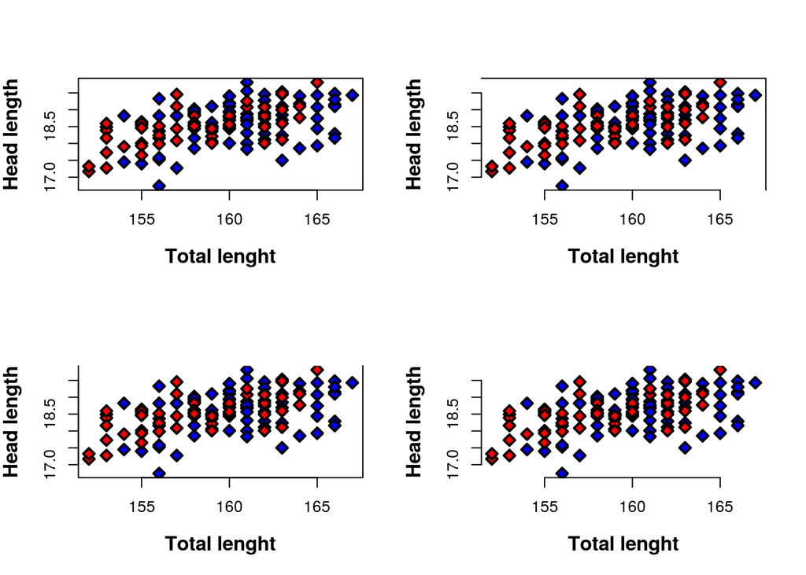

```r
plot(bumpus$HL~bumpus$TL, cex=1.25, col="black", pch=23,
     bg=ifelse(bumpus$sex=="f", "red", "blue"), lwd=2,
     xlab="Total lenght", ylab="Head length",
     cex.lab=1.25, font.lab=2)

plot(bumpus$HL~bumpus$TL, cex=1.25, col="black", pch=23,
     bg=ifelse(bumpus$sex=="f", "red", "blue"), lwd=2,
     xlab="Total lenght", ylab="Head length",
     cex.lab=1.25, font.lab=2, bty="7")

     plot(bumpus$HL~bumpus$TL, cex=1.25, col="black", pch=23,
     bg=ifelse(bumpus$sex=="f", "red", "blue"), lwd=2,
     xlab="Total lenght", ylab="Head length",
     cex.lab=1.25, font.lab=2, bty="u")

     plot(bumpus$HL~bumpus$TL, cex=1.25, col="black", pch=23,
     bg=ifelse(bumpus$sex=="f", "red", "blue"), lwd=2,
     xlab="Total lenght", ylab="Head length",
     cex.lab=1.25, font.lab=2, bty="n")
```

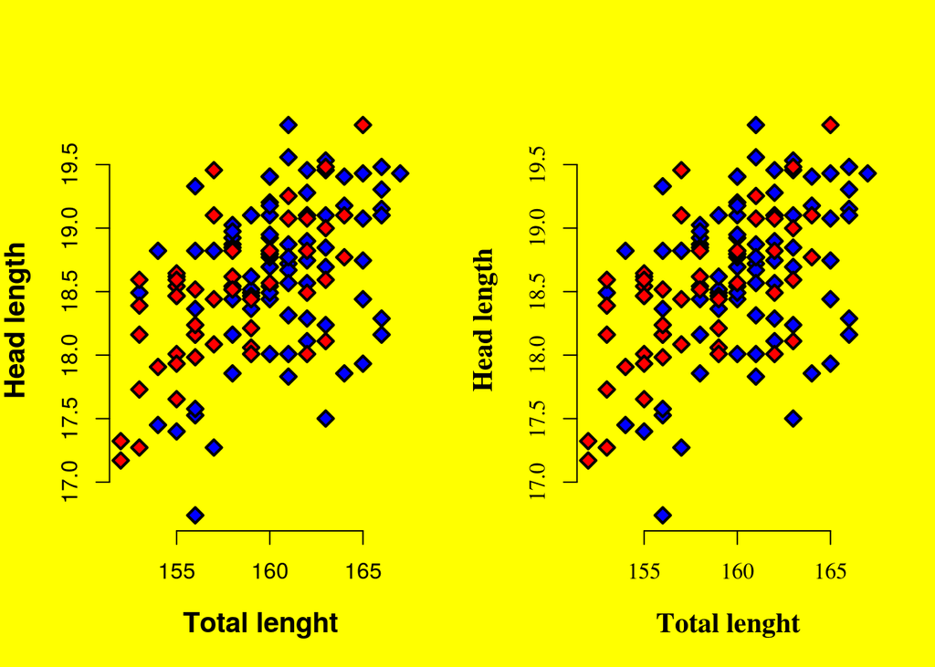

```r
# USING par()
layout(matrix(1:2, nrow=1, byrow=T))

par(bg="yellow")
plot(bumpus$HL~bumpus$TL, cex=1.25, col="black", pch=23,
     bg=ifelse(bumpus$sex=="f", "red", "blue"), lwd=2,
     xlab="Total lenght", ylab="Head length",
     cex.lab=1.25, font.lab=2, bty="n")

par(family="Times")
plot(bumpus$HL~bumpus$TL, cex=1.25, col="black", pch=23,
     bg=ifelse(bumpus$sex=="f", "red", "blue"), lwd=2,
     xlab="Total lenght", ylab="Head length",
     cex.lab=1.25, font.lab=2, bty="n")
```

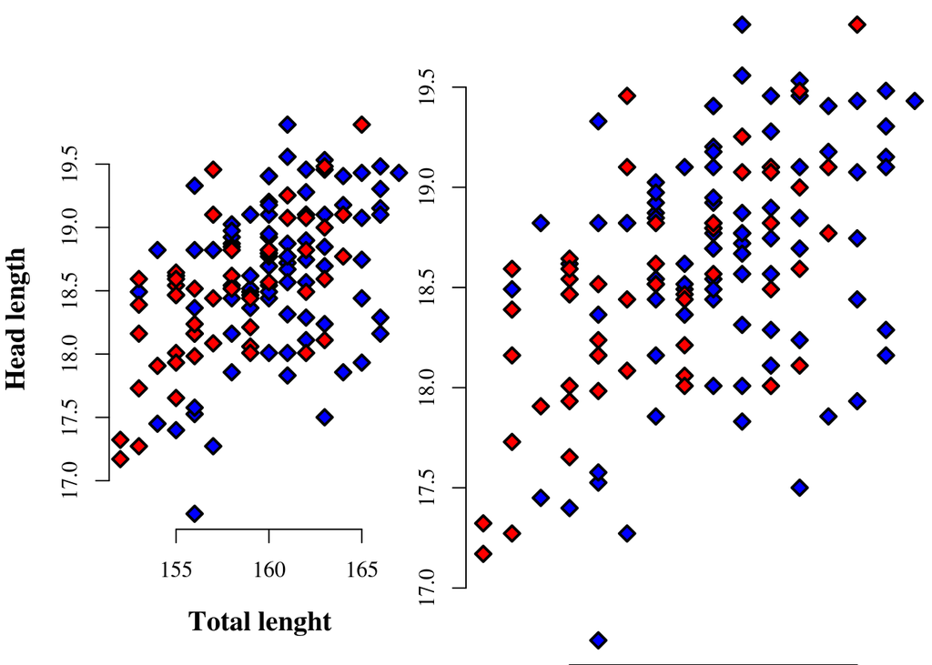

```r
layout(matrix(1:2, nrow=1, byrow=T))
# Setting both, family and bg:
par(family="Times", bg="white")
plot(bumpus$HL~bumpus$TL, cex=1.25, col="black", pch=23,
     bg=ifelse(bumpus$sex=="f", "red", "blue"), lwd=2,
     xlab="Total lenght", ylab="Head length",
     cex.lab=1.25, font.lab=2, bty="n")

#Setting the margins
par(mar=c(0,0,0,0))
plot(bumpus$HL~bumpus$TL, cex=1.25, col="black", pch=23,
     bg=ifelse(bumpus$sex=="f", "red", "blue"), lwd=2,
     xlab="Total lenght", ylab="Head length",
     cex.lab=1.25, font.lab=2, bty="n")
```

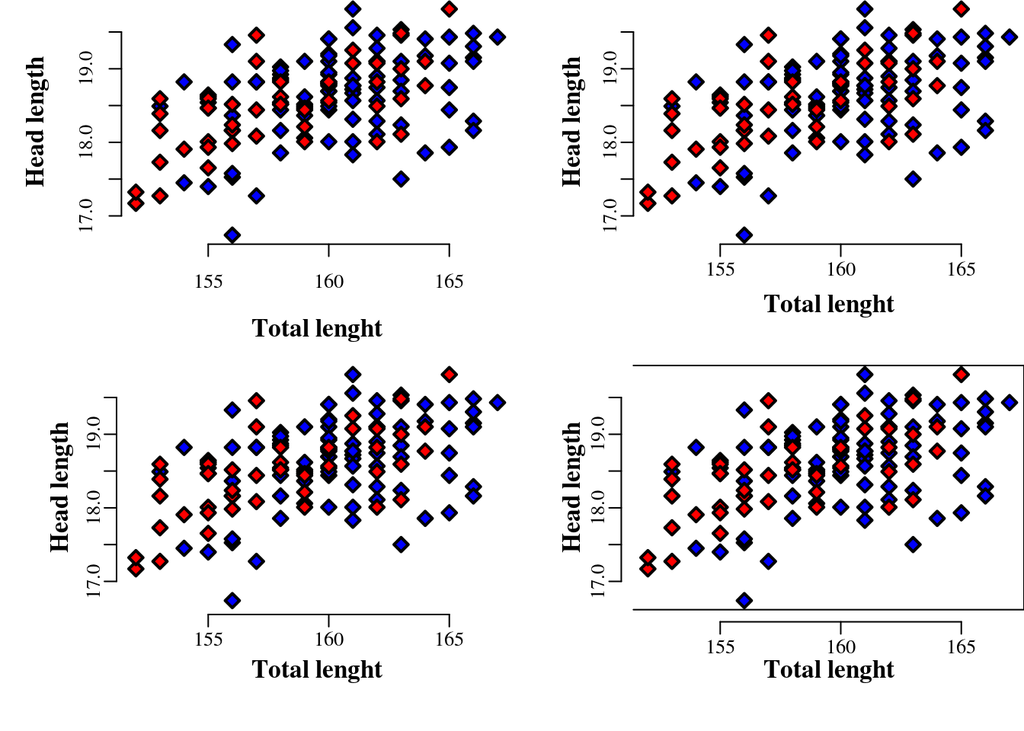

```r
# Plot margins
layout(matrix(1:4, nrow=2, byrow=T))
par(family="Times", bg="white", mar=c(5, 5, 0, 0))
plot(bumpus$HL~bumpus$TL, cex=1.25, col="black", pch=23,
     bg=ifelse(bumpus$sex=="f", "red", "blue"), lwd=2,
     xlab="Total lenght", ylab="Head length",
     cex.lab=1.25, font.lab=2, bty="n")

# Axis line and label spacing
par(family="Times", bg="white", mar=c(5, 5, 0, 0), mgp=c(2, 0.5, 0))
plot(bumpus$HL~bumpus$TL, cex=1.25, col="black", pch=23,
     bg=ifelse(bumpus$sex=="f", "red", "blue"), lwd=2,
     xlab="Total lenght", ylab="Head length",
     cex.lab=1.25, font.lab=2, bty="n")

par(family="Times", bg="white", mar=c(5, 5, 0, 0), mgp=c(2, 0.5, 0.2))
plot(bumpus$HL~bumpus$TL, cex=1.25, col="black", pch=23,
     bg=ifelse(bumpus$sex=="f", "red", "blue"), lwd=2,
     xlab="Total lenght", ylab="Head length",
     cex.lab=1.25, font.lab=2, bty="n")

par(family="Times", bg="white", mar=c(5, 5, 0, 0), mgp=c(2, 0.5, 0.5))
plot(bumpus$HL~bumpus$TL, cex=1.25, col="black", pch=23,
     bg=ifelse(bumpus$sex=="f", "red", "blue"), lwd=2,
     xlab="Total lenght", ylab="Head length",
     cex.lab=1.25, font.lab=2, bty="]")
```

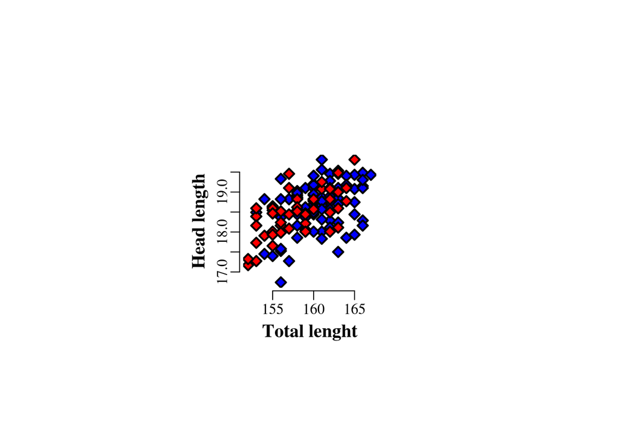

```r
# Plot size
layout(1)
par(family="Times", bg="white", mar=c(5, 5, 0, 0), mgp=c(2, 0.5, 0.2),
    pin=c(1.5, 1.5))
plot(bumpus$HL~bumpus$TL, cex=1.25, col="black", pch=23,
     bg=ifelse(bumpus$sex=="f", "red", "blue"), lwd=2,
     xlab="Total lenght", ylab="Head length",
     cex.lab=1.25, font.lab=2, bty="n")
```